# Validation of transferred Monaco annotations in PBMC and ileum

Author

Foo Cheung

## Purpose

This report evaluates the transferred Monaco annotations in the integrated PBMC and ileum object.

Transferred Monaco annotations were evaluated using canonical lineage marker expression across PBMC and ileum. Because Monaco and Pan-GI use different annotation hierarchies and nomenclature, validation focused primarily on marker expression, with Pan-GI used only to assess broad lineage concordance.

The goal is to evaluate whether Monaco-assigned populations express the expected canonical lineage markers. Direct one-to-one agreement with Pan-GI annotations is not expected because the two references use different annotation frameworks.

Monaco uses consistent methodology = whatever Monaco gets right, it gets right uniformly, and whatever it gets wrong, it gets wrong uniformly rather than introducing a tissue-specific bias that would differentially distort your PBMC-vs-ileum comparison.

## Annotation validation using canonical markers

Marker expression is the main validation used here because Monaco and Pan-GI use different annotation structures and naming conventions. Therefore, direct label concordance is not expected. Instead, we ask whether Monaco-labeled populations express the expected lineage markers.

## Main-level Monaco annotation validation

At the main annotation level, canonical lineage markers show the expected patterns across both PBMC and ileum. T-cell markers are enriched in T-cell populations, B-cell markers in B cells, myeloid markers in monocytes and dendritic cells, and granulocyte/basophil/progenitor markers in their expected populations. These patterns are consistent with the expected major immune lineages.

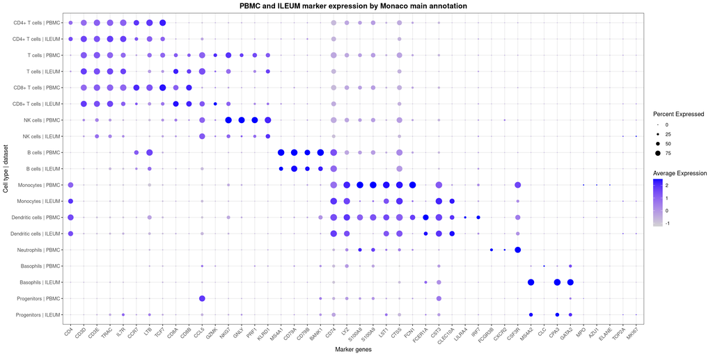

### Main-level interpretation

The main-level marker patterns look good. CD4 and CD8 T-cell populations show expected T-cell markers, NK cells show cytotoxic markers, B cells show B-cell markers, monocytes and dendritic cells show myeloid markers, and granulocyte/progenitor-associated markers are largely restricted to the expected populations.

Overall, the results support that the transferred Monaco annotations capture the expected major immune lineages in both PBMC and ileum. Differences between datasets are primarily quantitative and are consistent with differences in tissue composition.

## Fine-level Monaco annotation validation

At the fine annotation level, the expected lineage structure is also preserved. Related T-cell states show a gradual transition from naive/memory-like markers toward cytotoxic effector markers. B-cell populations retain expected B-cell markers, monocyte subsets show expected myeloid marker expression, and dendritic cell subsets show appropriate DC-associated markers.

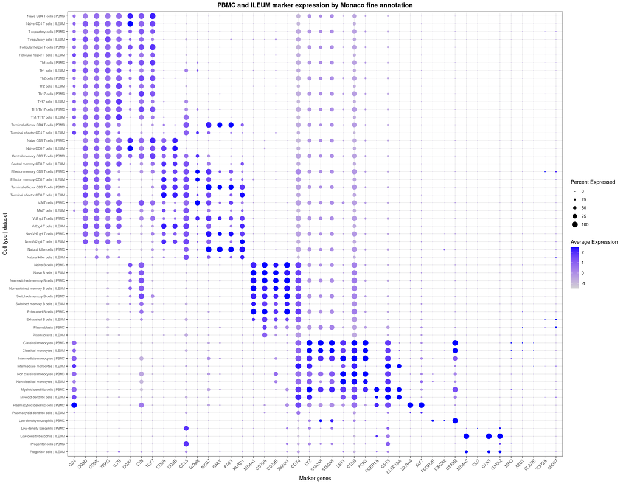

### Fine-level interpretation

The fine-level annotations also look biologically consistent. Naive and memory T-cell subsets retain expected T-cell markers, while effector and terminal effector CD8 and CD4 populations show stronger cytotoxic markers such as **CCL5**, **GZMK**, **NKG7**, **GNLY**, and **PRF1**. B-cell subsets show expected **MS4A1**, **CD79A**, **CD79B**, and **BANK1** expression, while plasmablasts show reduced classical B-cell marker patterns relative to other B-cell populations.

Monocyte subsets show expected enrichment of **LYZ**, **FCN1**, **LST1**, **CTSS**, **S100A8**, and **S100A9**, and dendritic cell populations show expected expression of markers such as **FCER1A**, **CLEC10A**, **LILRA4**, and **IRF7**. Basophil and progenitor-associated markers are also largely restricted to the expected rare populations.

These patterns support the biological plausibility of the transferred Monaco fine annotations. Although marker expression alone cannot verify every individual cell assignment, the group-level patterns are consistent with expected immune lineage biology across PBMC and ileum.

## Monaco annotation confidence scores

As an additional validation step, this section examines Monaco annotation confidence scores for all cells in PBMC and ileum. Confidence is interpreted as similarity to the Monaco reference, not as absolute proof that an annotation is correct. Because Monaco is PBMC-derived, ileum cells may show modestly lower confidence even when broad lineage identity is correct.

```
Candidate confidence/score columns:
```

```
 [1] "HTO_maxID"          "ambient_rna_score"  "scDblFinder_Score"
 [4] "scds_Score"         "scrublet_Score"     "doublet_confidence"
 [7] "Monaco_main_scores" "Monaco_fine_scores" "HPCA_main_scores"
[10] "HPCA_fine_scores"   "EpithelialScore"    "PanGI_L1_score"
[13] "PanGI_L2_score"     "PanGI_L3_score"
```

```
# A tibble: 2 × 10
  dataset n_cells main_median main_IQR_low main_IQR_high main_mean fine_median
  <fct>     <int>       <dbl>        <dbl>         <dbl>     <dbl>       <dbl>
1 PBMC     131165       0.482        0.423         0.622     0.509       0.424
2 ILEUM     67869       0.418        0.376         0.443     0.401       0.369
# ℹ 3 more variables: fine_IQR_low <dbl>, fine_IQR_high <dbl>, fine_mean <dbl>
```

### Main-level confidence by cell type

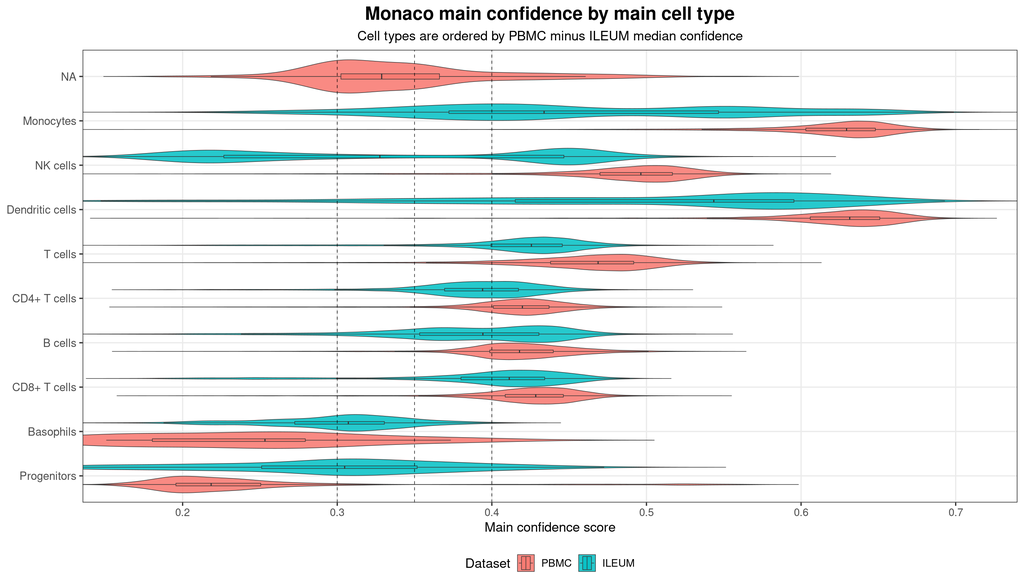

### Fine-level confidence by cell type

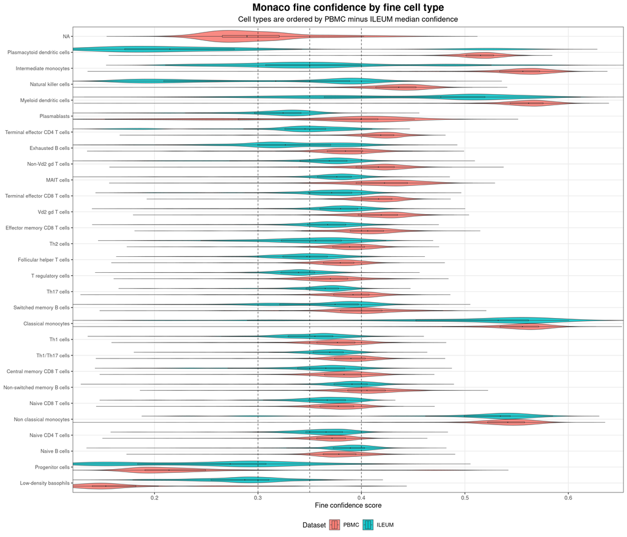

### Confidence-score interpretation

At the Monaco fine annotation level, most adaptive immune populations retain overlapping PBMC and ileum confidence distributions. Larger differences are concentrated in specific tissue-adapted or rare populations, including NK cells, dendritic cell subsets, MAIT cells, terminal effector T cells and low-density granulocyte/progenitor populations. This pattern suggests tissue-specific transcriptional divergence rather than global annotation failure.

Taken together, marker-expression validation and confidence-score distributions support Monaco annotations as suitable for broad cross-tissue immune-lineage comparisons, while still motivating caution for specialized tissue-resident or low-confidence fine subsets.

## Marker consistency across disease/treatment groups

```
    ILEUM | Spike   ILEUM | Treated ILEUM | Untreated         PBMC | HC
             6484             21782             39603             31528
    PBMC | Severe    PBMC | Treated  PBMC | Untreated
            36205             31627             31805
```

### Monaco main annotations across dataset/condition groups

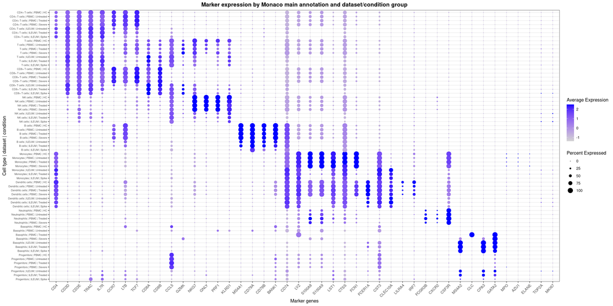

### Monaco fine annotations across dataset/condition groups

This figure is larger because the fine annotation has many more labels. It is useful as a supplemental QC plot if there is concern that condition or treatment status changes annotation behavior.

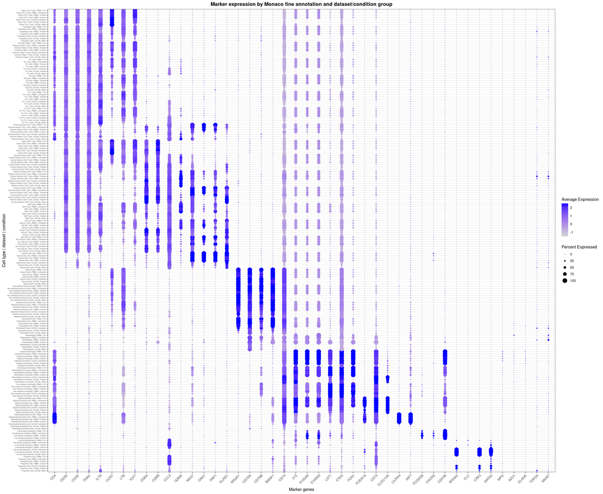

### Interpretation

These group-stratified dot plots are intended as a robustness check. If the same Monaco-defined populations continue to express the expected canonical markers across healthy, untreated, and treated groups, this supports that the annotations are stable across biological conditions. Differences in marker intensity across groups should be interpreted cautiously because they may reflect true biology, treatment effects, disease severity, or differences in cell number rather than annotation failure.

## Concordance between Monaco and PanGI annotations

The Monaco and PanGI annotation frameworks were developed using different reference atlases and therefore are not expected to exhibit one-to-one correspondence. To complement the marker-based validation above, we summarized how Monaco annotations map onto PanGI annotations.

### Monaco main vs PanGI L1

| Monaco_main | PanGI_L1 | dataset | n | total_cells | percent |
| --- | --- | --- | --- | --- | --- |
| B cells | B and B plasma | ILEUM | 12140 | 12160 | 99.84 |
| Monocytes | Myeloid | ILEUM | 968 | 968 | 100.00 |
| Dendritic cells | Myeloid | ILEUM | 1184 | 1267 | 93.45 |
| Basophils | Myeloid | ILEUM | 485 | 492 | 98.58 |
| CD4+ T cells | T and NK cells | ILEUM | 4634 | 4639 | 99.89 |
| T cells | T and NK cells | ILEUM | 41593 | 41642 | 99.88 |
| CD8+ T cells | T and NK cells | ILEUM | 1127 | 1127 | 100.00 |
| NK cells | T and NK cells | ILEUM | 5429 | 5460 | 99.43 |

Broad lineage agreement was excellent, with nearly all Monaco main populations mapping to the expected PanGI L1 immune compartment.

### Monaco fine vs PanGI L2

| Monaco_fine | PanGI_L2 | n | total_cells | percent |
| --- | --- | --- | --- | --- |
| Naive CD4 T cells | Conventional_CD4 | 501 | 542 | 92.44 |
| T regulatory cells | Treg | 1258 | 2217 | 56.74 |
| T regulatory cells | Conventional_CD4 | 902 | 2217 | 40.69 |
| Follicular helper T cells | Conventional_CD4 | 533 | 757 | 70.41 |
| Follicular helper T cells | Treg | 222 | 757 | 29.33 |
| Th1 cells | Conventional_CD4 | 498 | 680 | 73.24 |
| Th1 cells | Treg | 149 | 680 | 21.91 |
| Th2 cells | Conventional_CD4 | 99 | 117 | 84.62 |
| Th2 cells | Treg | 16 | 117 | 13.68 |
| Th17 cells | Conventional_CD4 | 263 | 282 | 93.26 |
| Th17 cells | Treg | 19 | 282 | 6.74 |
| Th1/Th17 cells | Conventional_CD4 | 2539 | 2770 | 91.66 |
| Th1/Th17 cells | Treg | 210 | 2770 | 7.58 |
| Terminal effector CD4 T cells | Conventional_CD4 | 30 | 51 | 58.82 |
| Terminal effector CD4 T cells | Conventional_CD8 | 17 | 51 | 33.33 |
| Naive CD8 T cells | Conventional_CD8 | 183 | 213 | 85.92 |
| Naive CD8 T cells | Conventional_CD4 | 30 | 213 | 14.08 |
| Central memory CD8 T cells | Conventional_CD8 | 929 | 1275 | 72.86 |
| Central memory CD8 T cells | Conventional_CD4 | 294 | 1275 | 23.06 |
| Effector memory CD8 T cells | Conventional_CD8 | 2779 | 3312 | 83.91 |
| Effector memory CD8 T cells | Conventional_CD4 | 297 | 3312 | 8.97 |
| Terminal effector CD8 T cells | Conventional_CD8 | 480 | 701 | 68.47 |
| Terminal effector CD8 T cells | Unconventional_T/ILC | 203 | 701 | 28.96 |
| MAIT cells | Conventional_CD4 | 7265 | 13857 | 52.43 |
| MAIT cells | Conventional_CD8 | 5557 | 13857 | 40.10 |
| MAIT cells | Unconventional_T/ILC | 858 | 13857 | 6.19 |
| Vd2 gd T cells | Conventional_CD8 | 7952 | 10881 | 73.08 |
| Vd2 gd T cells | Unconventional_T/ILC | 2069 | 10881 | 19.01 |
| Vd2 gd T cells | Conventional_CD4 | 787 | 10881 | 7.23 |
| Non-Vd2 gd T cells | Conventional_CD8 | 5410 | 9244 | 58.52 |
| Non-Vd2 gd T cells | Unconventional_T/ILC | 3293 | 9244 | 35.62 |
| Natural killer cells | Unconventional_T/ILC | 2600 | 5903 | 44.05 |
| Natural killer cells | Conventional_CD8 | 1666 | 5903 | 28.22 |
| Natural killer cells | NK | 967 | 5903 | 16.38 |
| Natural killer cells | Conventional_CD4 | 483 | 5903 | 8.18 |
| Naive B cells | Mature_B | 2447 | 2456 | 99.63 |
| Non-switched memory B cells | Mature_B | 1895 | 1903 | 99.58 |
| Switched memory B cells | Mature_B | 1956 | 2760 | 70.87 |
| Switched memory B cells | B_plasma | 796 | 2760 | 28.84 |
| Exhausted B cells | B_plasma | 374 | 656 | 57.01 |
| Exhausted B cells | Mature_B | 278 | 656 | 42.38 |
| Plasmablasts | B_plasma | 4367 | 4370 | 99.93 |
| Classical monocytes | Monocyte | 84 | 100 | 84.00 |
| Classical monocytes | DC | 8 | 100 | 8.00 |
| Classical monocytes | Macrophage | 8 | 100 | 8.00 |
| Intermediate monocytes | Macrophage | 343 | 376 | 91.22 |
| Intermediate monocytes | Monocyte | 23 | 376 | 6.12 |
| Non classical monocytes | Monocyte | 28 | 33 | 84.85 |
| Non classical monocytes | DC | 3 | 33 | 9.09 |
| Non classical monocytes | Macrophage | 2 | 33 | 6.06 |
| Myeloid dendritic cells | Macrophage | 1027 | 1650 | 62.24 |
| Myeloid dendritic cells | DC | 551 | 1650 | 33.39 |
| Plasmacytoid dendritic cells | B_plasma | 67 | 93 | 72.04 |
| Plasmacytoid dendritic cells | DC | 18 | 93 | 19.35 |
| Low-density basophils | Granulocyte | 443 | 455 | 97.36 |
| Progenitor cells | Granulocyte | 99 | 215 | 46.05 |
| Progenitor cells | Unconventional_T/ILC | 56 | 215 | 26.05 |
| Progenitor cells | B_plasma | 18 | 215 | 8.37 |
| Progenitor cells | Conventional_CD4 | 18 | 215 | 8.37 |
| Progenitor cells | Conventional_CD8 | 17 | 215 | 7.91 |

## Integrated UMAP review

The UMAP plots are included after the marker validation to assess the structure of the integrated embedding. These plots are useful for checking whether PBMC and ileum occupy comparable immune-cell space after Harmony and whether Monaco annotations form coherent regions. However, UMAPs are supportive rather than definitive; the dot plots above provide the stronger biological validation.

### UMAP colored by dataset

This plot checks whether PBMC and ileum cells occupy the integrated space in a way that is compatible with shared immune cell states. Strong separation by dataset alone would suggest residual dataset or tissue effects, whereas overlap within immune lineages supports the integrated annotation strategy.

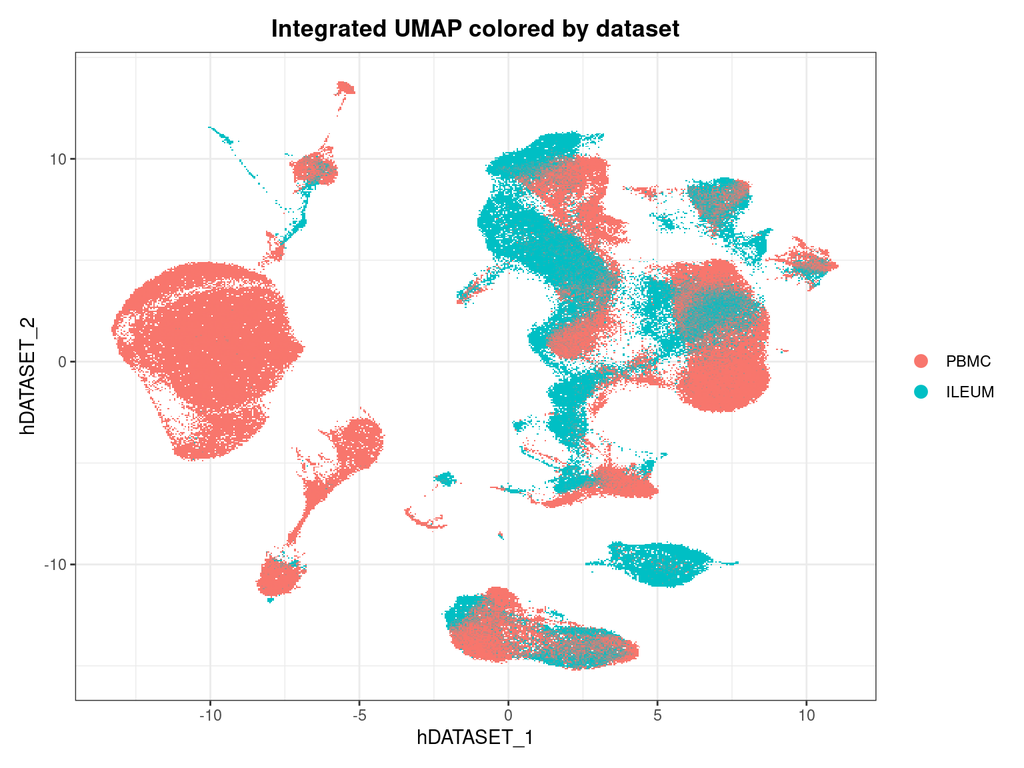

### UMAP colored by Monaco main annotation

This plot evaluates whether broad Monaco annotations form coherent immune lineage regions in the embedding.

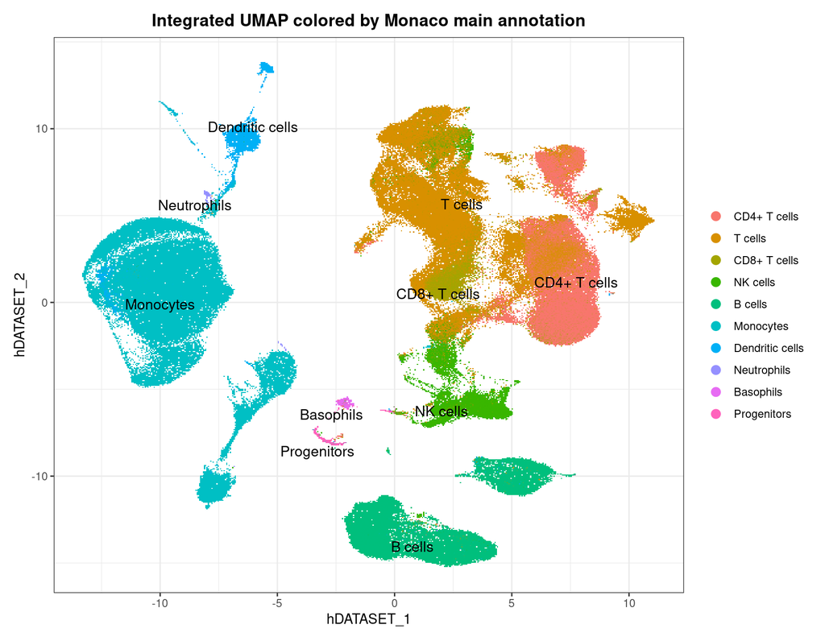

### UMAP colored by PanGI L1 annotation

This plot evaluates whether broad PanGI L1 annotations form coherent immune lineage regions in the embedding.

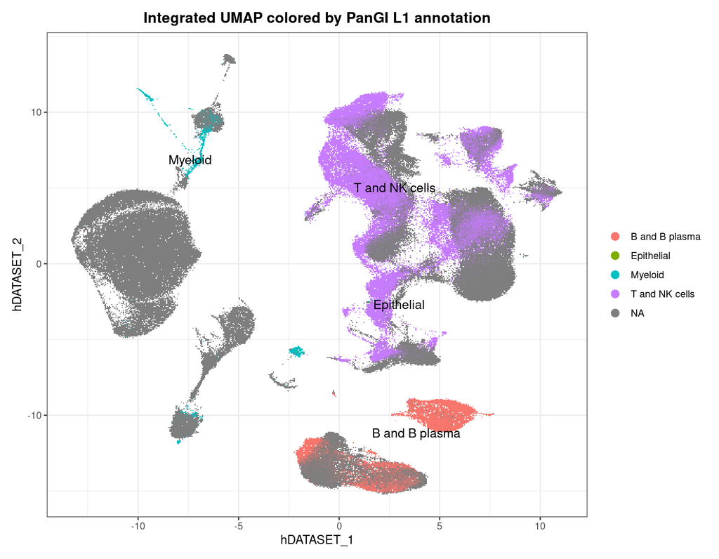

### UMAP colored by Monaco fine annotation

This plot evaluates whether fine Monaco annotations show coherent structure. Fine labels are expected to overlap more than main labels because related immune states share transcriptional programs, but broadly related groups should still occupy plausible regions.

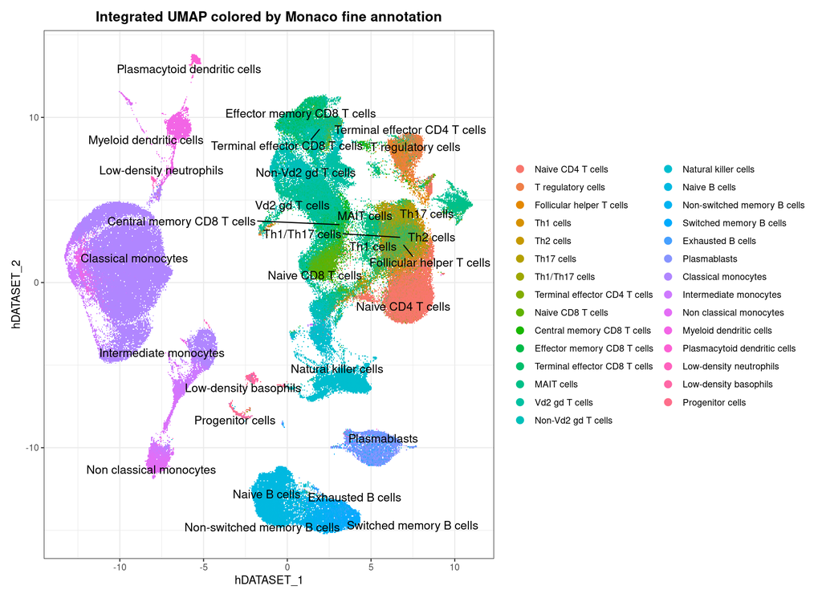

### UMAP colored by PanGI L2 annotation

This plot evaluates whether broad PanGI L2 annotations form coherent immune lineage regions in the embedding.

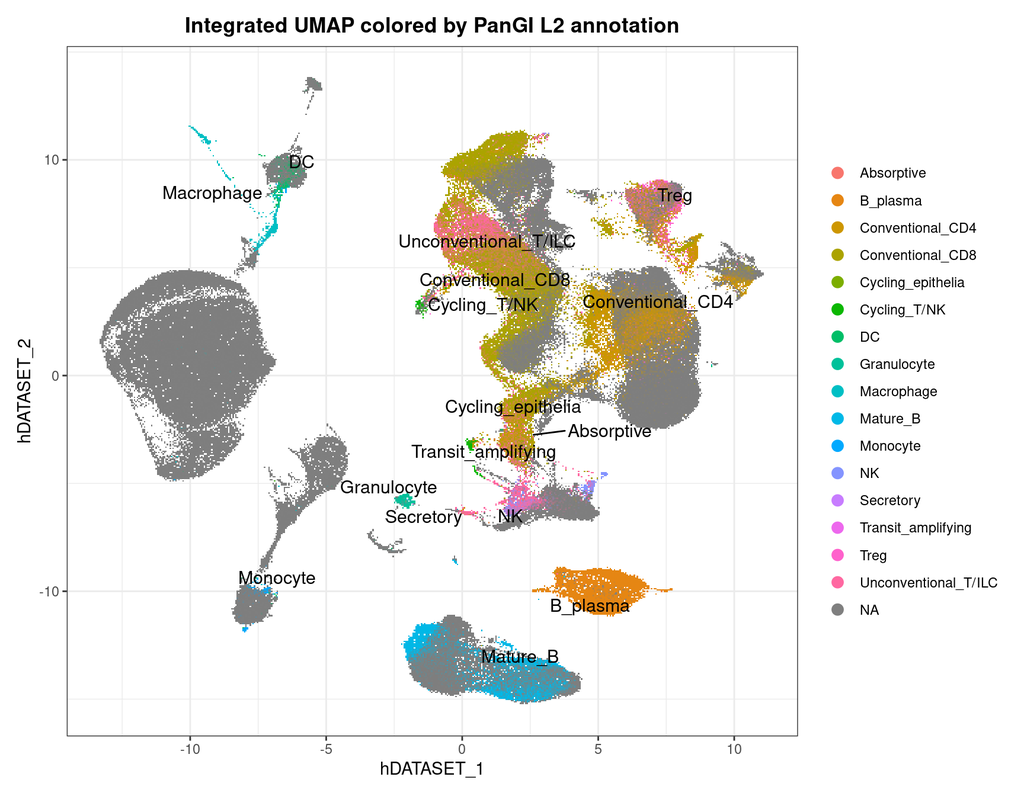

### Dataset-specific UMAP panels

Splitting the UMAP by dataset makes it easier to confirm whether the same annotated populations are present in PBMC and ileum separately. These plots should be interpreted together with the dot plots, because UMAP structure alone does not validate marker identity.

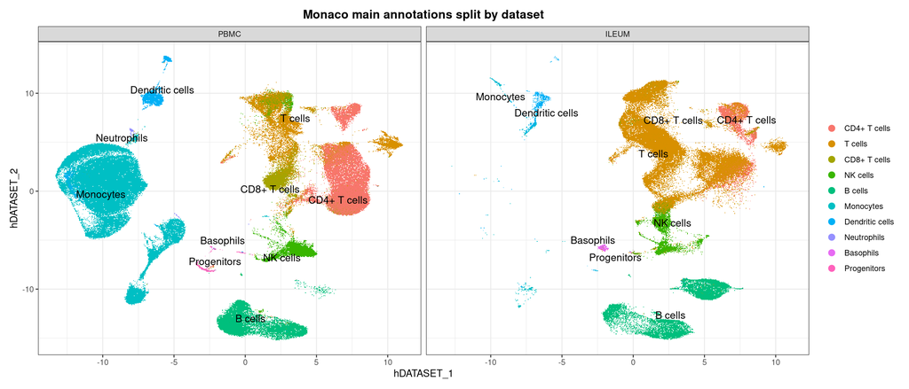

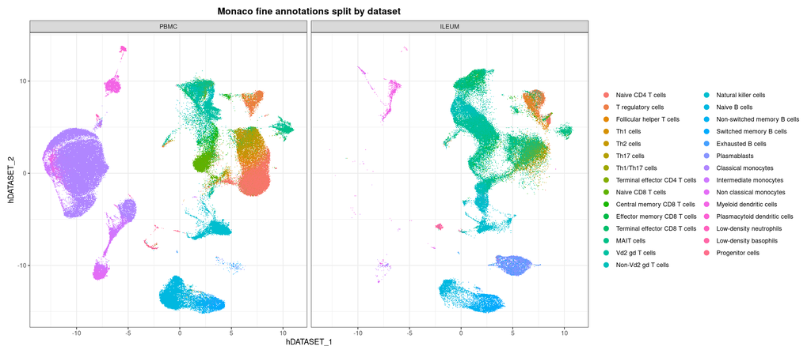

### UMAP interpretation

After Harmony integration, PBMC and ileum cells are expected to show a combination of shared and dataset-specific regions. Overlap within immune lineages supports alignment of shared cell states across datasets, while dataset-enriched regions are expected because blood and intestinal tissue contain different cell states and tissue-specific populations.

The UMAPs complement the marker analyses by illustrating the integrated embedding and the spatial organization of the transferred annotations. Marker expression provides the primary evidence for annotation consistency.

## Cell composition summary

Cell composition is useful for documenting expected biological differences between PBMC and ileum. These summaries do not validate the annotations by themselves, but they help show whether each dataset contains the expected major immune compartments and whether rare populations are present.

```
# A tibble: 19 × 4
   dataset Monaco_main     n_cells  percent
   <fct>   <fct>             <int>    <dbl>
 1 PBMC    CD4+ T cells      29324 22.4
 2 PBMC    T cells           15114 11.5
 3 PBMC    CD8+ T cells       7947  6.06
 4 PBMC    NK cells           8001  6.10
 5 PBMC    B cells           14292 10.9
 6 PBMC    Monocytes         51171 39.0
 7 PBMC    Dendritic cells    4161  3.17
 8 PBMC    Neutrophils         264  0.201
 9 PBMC    Basophils             8  0.00610
10 PBMC    Progenitors         883  0.673
11 ILEUM   CD4+ T cells       4639  6.84
12 ILEUM   T cells           41642 61.4
13 ILEUM   CD8+ T cells       1127  1.66
14 ILEUM   NK cells           5460  8.04
15 ILEUM   B cells           12160 17.9
16 ILEUM   Monocytes           968  1.43
17 ILEUM   Dendritic cells    1267  1.87
18 ILEUM   Basophils           492  0.725
19 ILEUM   Progenitors         114  0.168
```

```
# A tibble: 57 × 4
   dataset Monaco_fine                   n_cells percent
   <fct>   <fct>                           <int>   <dbl>
 1 PBMC    Naive CD4 T cells               18082  13.8
 2 PBMC    T regulatory cells               3529   2.69
 3 PBMC    Follicular helper T cells        1881   1.43
 4 PBMC    Th1 cells                        1663   1.27
 5 PBMC    Th2 cells                        2176   1.66
 6 PBMC    Th17 cells                       1633   1.24
 7 PBMC    Th1/Th17 cells                   2048   1.56
 8 PBMC    Terminal effector CD4 T cells     675   0.515
 9 PBMC    Naive CD8 T cells                6531   4.98
10 PBMC    Central memory CD8 T cells       1789   1.36
# ℹ 47 more rows
```

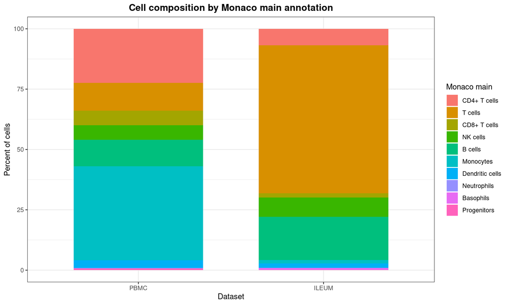

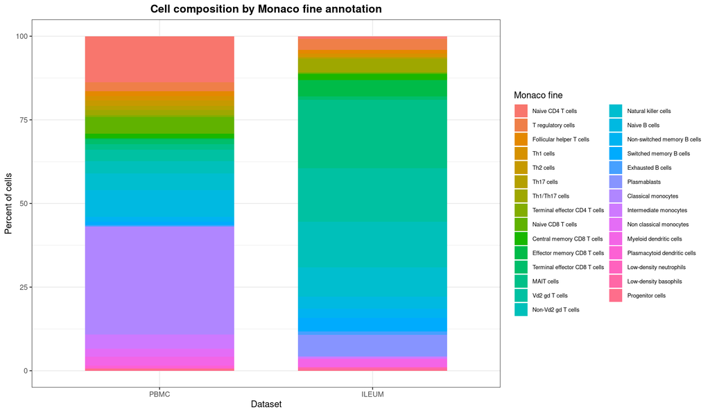

## Summary conclusion

The transferred Monaco annotations are supported by canonical marker expression at both the main and fine annotation levels. Expected lineage markers localize to the appropriate Monaco-defined populations across PBMC and ileum.

Because Monaco and Pan-GI use different annotation hierarchies and levels of granularity, direct one-to-one label concordance is not expected. Marker expression serves as the primary validation, while UMAP structure and broad Pan-GI lineage concordance provide complementary supporting evidence.